# EDA Diamond Prices Part 1

### 1. Diamonds

Load the Diamonds data set

- How many observations are in the data set? **53,940**
- How many variables? **10**
- How many ordered factors? **3**
- What letter represents the best color? **D**

```r
library(ggplot2)
str(diamonds)
```

```
## Classes 'tbl_df', 'tbl' and 'data.frame':    53940 obs. of  10 variables:
##  $ carat  : num  0.23 0.21 0.23 0.29 0.31 0.24 0.24 0.26 0.22 0.23 ...
##  $ cut    : Ord.factor w/ 5 levels "Fair"<"Good"<..: 5 4 2 4 2 3 3 3 1 3 ...
##  $ color  : Ord.factor w/ 7 levels "D"<"E"<"F"<"G"<..: 2 2 2 6 7 7 6 5 2 5 ...
##  $ clarity: Ord.factor w/ 8 levels "I1"<"SI2"<"SI1"<..: 2 3 5 4 2 6 7 3 4 5 ...
##  $ depth  : num  61.5 59.8 56.9 62.4 63.3 62.8 62.3 61.9 65.1 59.4 ...
##  $ table  : num  55 61 65 58 58 57 57 55 61 61 ...
##  $ price  : int  326 326 327 334 335 336 336 337 337 338 ...
##  $ x      : num  3.95 3.89 4.05 4.2 4.34 3.94 3.95 4.07 3.87 4 ...
##  $ y      : num  3.98 3.84 4.07 4.23 4.35 3.96 3.98 4.11 3.78 4.05 ...
##  $ z      : num  2.43 2.31 2.31 2.63 2.75 2.48 2.47 2.53 2.49 2.39 ...
```

### 2. Price Histogram

Create a histogram of the price of all the diamonds in the diamond data set

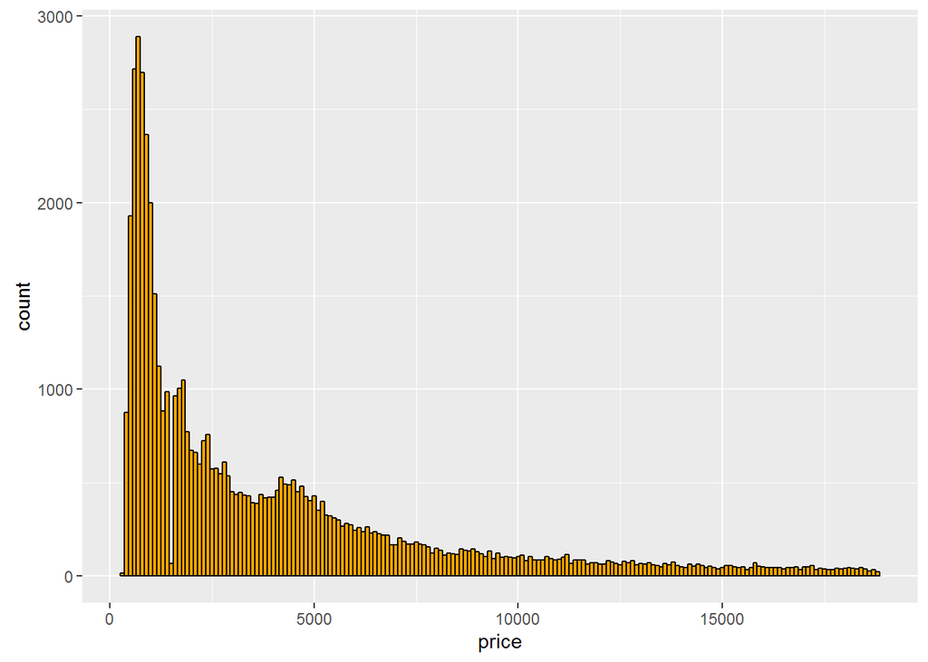

```r
qplot(x = price, data = diamonds, binwidth = 100, color = I("black"), fill = I("orange"))
```

### 3. Price Histogram Summary

Describe the shape and centre of the distribution.Include summary statistics.

**The histogram represents a right skewed distribution, with a median of $2,401 and a mean of $3,933**

```r
summary(diamonds$price)
```

```
##    Min. 1st Qu.  Median    Mean 3rd Qu.    Max.
##     326     950    2401    3933    5324   18820
```

### 4. Diamond Counts

- How many diamonds cost under $500? **1,729**
- How many diamonds cost under $250? **0**
- How many diamonds cost $15,000 or more? **1,656**

```r
sum(diamonds$price < 500)
```

```
## [1] 1729
```

```r
sum(diamonds$price < 250)
```

```
## [1] 0
```

```r
sum(diamonds$price >= 15000)
```

```
## [1] 1656
```

### 5. Cheaper Diamonds

Explore the largest peak in the price histogram you created earlier. Try limiting the x-axis, altering the bin width, and setting different breaks on the x-axis.

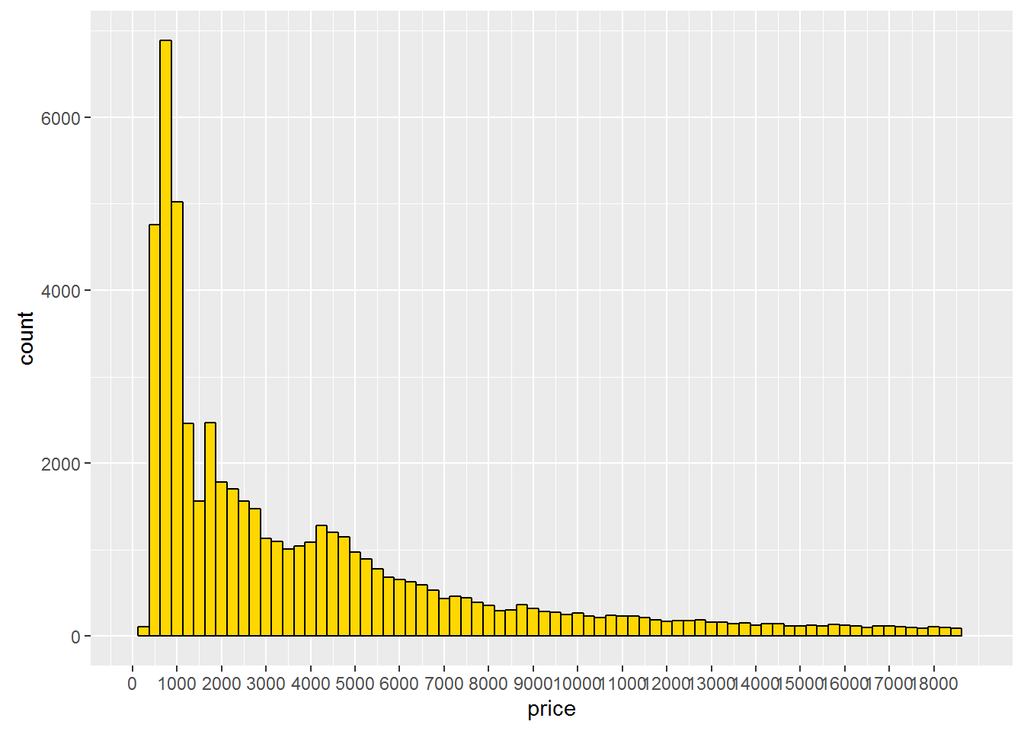

```r
qplot(x = price, data = diamonds, binwidth = 250, color = I("black"), fill = I("gold")) +
  scale_x_continuous(limits = c(0, 18823), breaks = seq(0, 18823, 1000))
```

### 6. Price by Cut Histograms

Break out the histogram of diamond prices by cut.You should have five histograms in separate panels on your resulting plot.

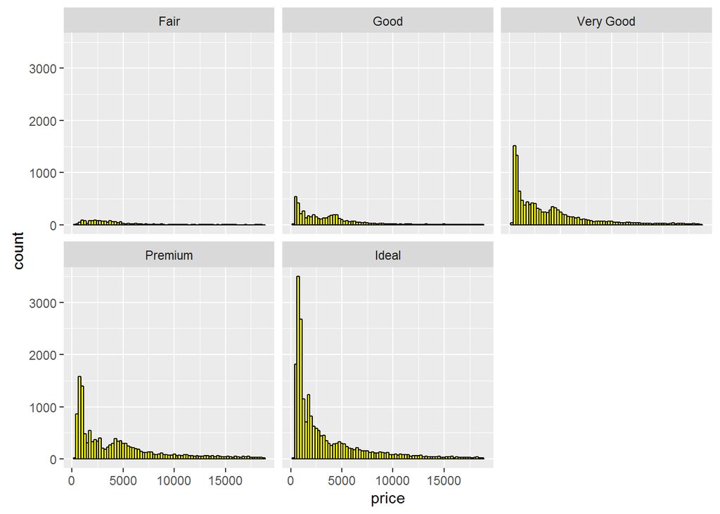

```r
qplot(x = price, data = diamonds, binwidth = 250, color = I("black"), fill = I("yellow")) +
  facet_wrap(~cut)
```

### 7. Price by Cut

- Which cut has the highest priced diamond? **Premium**
- Which cut has the lowest priced diamond? **Premium and Ideal**
- Which cut has the lowest median price? **Ideal**

```r
library(dplyr)
```

```r
filter(diamonds, price == max(diamonds$price))
```

```
## Source: local data frame [1 x 10]
##
##   carat     cut  color clarity depth table price     x     y     z
##   (dbl)  (fctr) (fctr)  (fctr) (dbl) (dbl) (int) (dbl) (dbl) (dbl)
## 1  2.29 Premium      I     VS2  60.8    60 18823   8.5  8.47  5.16
```

```r
filter(diamonds, price == min(diamonds$price))
```

```
## Source: local data frame [2 x 10]
##
##   carat     cut  color clarity depth table price     x     y     z
##   (dbl)  (fctr) (fctr)  (fctr) (dbl) (dbl) (int) (dbl) (dbl) (dbl)
## 1  0.23   Ideal      E     SI2  61.5    55   326  3.95  3.98  2.43
## 2  0.21 Premium      E     SI1  59.8    61   326  3.89  3.84  2.31
```

```r
table(diamonds$cut)
```

```
##
##      Fair      Good Very Good   Premium     Ideal
##      1610      4906     12082     13791     21551
```

```r
  by(diamonds$price, diamonds$cut, summary)
```

```
## diamonds$cut: Fair
##    Min. 1st Qu.  Median    Mean 3rd Qu.    Max.
##     337    2050    3282    4359    5206   18570
## --------------------------------------------------------
## diamonds$cut: Good
##    Min. 1st Qu.  Median    Mean 3rd Qu.    Max.
##     327    1145    3050    3929    5028   18790
## --------------------------------------------------------
## diamonds$cut: Very Good
##    Min. 1st Qu.  Median    Mean 3rd Qu.    Max.
##     336     912    2648    3982    5373   18820
## --------------------------------------------------------
## diamonds$cut: Premium
##    Min. 1st Qu.  Median    Mean 3rd Qu.    Max.
##     326    1046    3185    4584    6296   18820
## --------------------------------------------------------
## diamonds$cut: Ideal
##    Min. 1st Qu.  Median    Mean 3rd Qu.    Max.
##     326     878    1810    3458    4678   18810
```

### 8. Scales and Multiple Histograms

Add a parameter to facet_wrap so that the y-axis in the histograms is not fixed. You want the y-axis to be different for each histogram.

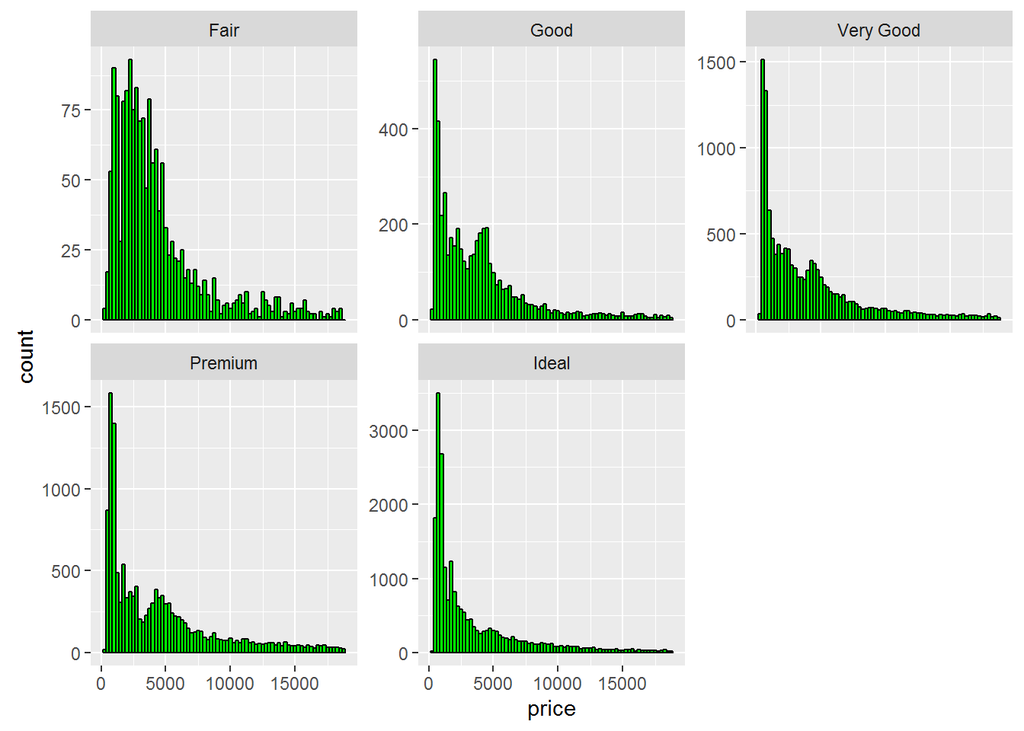

```r
qplot(x = price, data = diamonds, binwidth = 250, color = I("black"), fill = I("green")) +
  facet_wrap(~cut, scales = "free_y")
```

### 9. Price per Carat by Cut

Create a histogram of price per carat and facet it by cut. Adjust the bin width and transform the scale of the x-axis using log10.

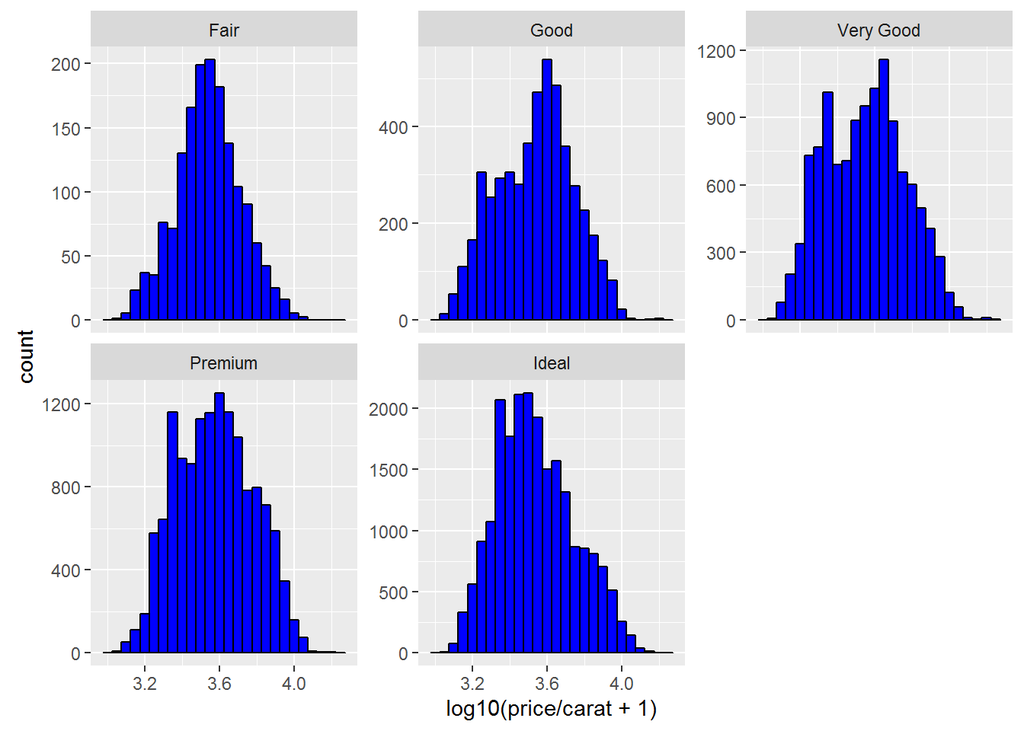

```r
qplot(x = log10(price/carat + 1), data = diamonds, binwidth = 0.05, color = I("black"), fill = I("blue")) +
  facet_wrap(~cut, scales = "free_y")
```

### 10. Price Box Plots

Investigate the price of diamonds using box plots, numerical summaries, and one of the following categorical variables: cut, clarity, or color.

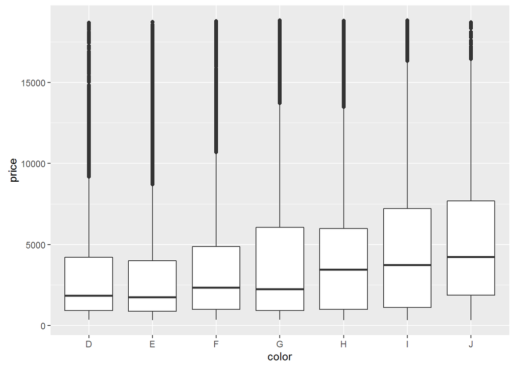

```r
qplot(x = color, y = price, data = diamonds, geom = "boxplot")
```

```r
table(diamonds$color)
```

```
##
##     D     E     F     G     H     I     J
##  6775  9797  9542 11292  8304  5422  2808
```

```r
  by(diamonds$price, diamonds$color, summary)
```

```
## diamonds$color: D
##    Min. 1st Qu.  Median    Mean 3rd Qu.    Max.
##     357     911    1838    3170    4214   18690
## --------------------------------------------------------
## diamonds$color: E
##    Min. 1st Qu.  Median    Mean 3rd Qu.    Max.
##     326     882    1739    3077    4003   18730
## --------------------------------------------------------
## diamonds$color: F
##    Min. 1st Qu.  Median    Mean 3rd Qu.    Max.
##     342     982    2344    3725    4868   18790
## --------------------------------------------------------
## diamonds$color: G
##    Min. 1st Qu.  Median    Mean 3rd Qu.    Max.
##     354     931    2242    3999    6048   18820
## --------------------------------------------------------
## diamonds$color: H
##    Min. 1st Qu.  Median    Mean 3rd Qu.    Max.
##     337     984    3460    4487    5980   18800
## --------------------------------------------------------
## diamonds$color: I
##    Min. 1st Qu.  Median    Mean 3rd Qu.    Max.
##     334    1120    3730    5092    7202   18820
## --------------------------------------------------------
## diamonds$color: J
##    Min. 1st Qu.  Median    Mean 3rd Qu.    Max.
##     335    1860    4234    5324    7695   18710
```

### 11. Interquartile Range

- What is the price range for the middle 50% of diamonds with color D? **911 - 4,214**
- What is the price range for the middle 50% of diamonds with color J? **1,861 - 7,695**
- What is the IQR for diamonds with the best color? **3,303**
- What is the IQR for diamonds with the worst color? **5,835**

**All figures are available in the summary tables by diamond color above**

Can also find IQR as follows:

```r
IQR(diamonds$price[diamonds$color == "D"])
```

```
## [1] 3302.5
```

```r
IQR(diamonds$price[diamonds$color == "J"])
```

```
## [1] 5834.5
```

### 12. Price per Carat Box Plots by Color

Investigate the price per carat of diamonds across the different colors of diamonds using boxplots.

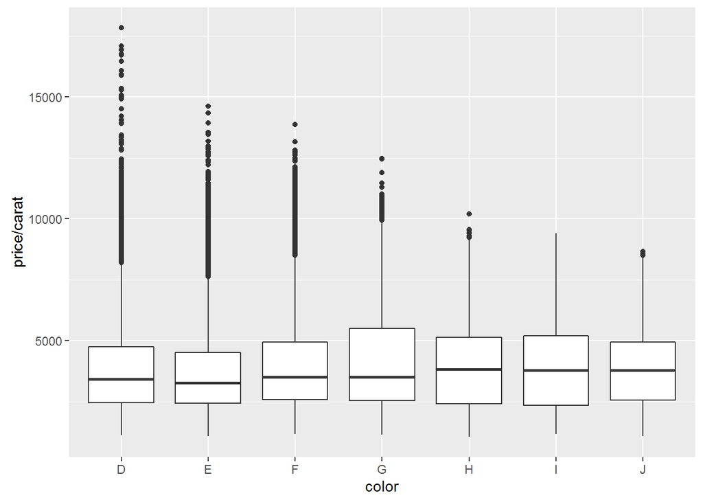

```r
qplot(x = color, y = price/carat, data = diamonds, geom = "boxplot")
```

### 13. Carat Frequency Polygon

Invesitgate the weight of diamonds using a frequency polygon.

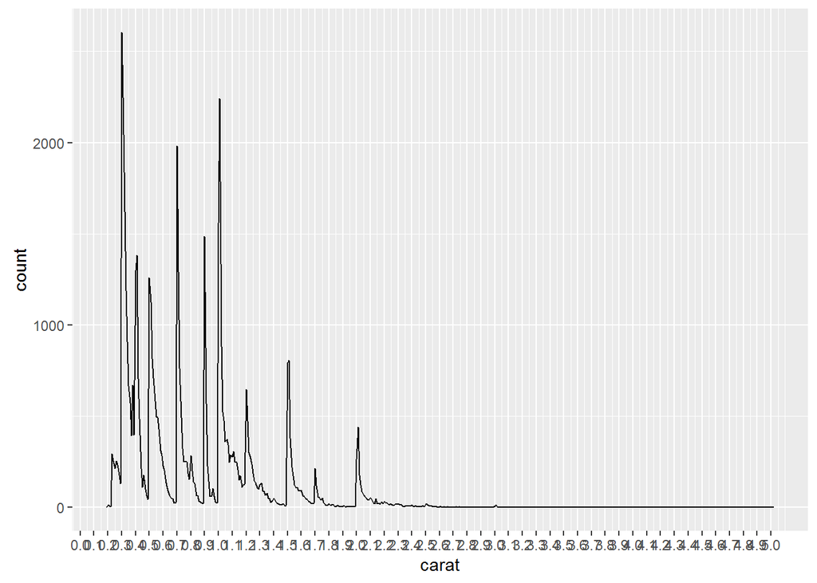

```r
qplot(x = carat, data = subset(diamonds, !is.na(carat)), geom = "freqpoly", binwidth = 0.01) +
  scale_x_continuous(breaks = seq(0, 5, 0.1))
```

```r
filter(count(diamonds, carat, carat > 2000), n > 2000)
```

```
## Source: local data frame [3 x 3]
## Groups: carat [3]
##
##   carat carat > 2000     n
##   (dbl)        (lgl) (int)
## 1  0.30        FALSE  2604
## 2  0.31        FALSE  2249
## 3  1.01        FALSE  2242
```

### 14. Data Wrngling in R

tidyr -a package that reshapes the layout of your data

dplyr - a package that helps you transform tidy, tabular data

### 15. Gapminder Data

Download a data set of your choice and create 2-5 plots that make use of the techniques from Lesson 3. You might use a simple histogram, a boxplot split over a categorical variable, or a frequency polygon. The choice is yours! You can find a link to the Gapminder website in the Instructor Notes.

Once you’ve completed your investigation, create a post in the discussions that includes:

- any questions you answered, your observations, and summary statistics
- snippets of code that created the plots
- links to the images of your plots

**Each year, countries are scored on how corrupt their public sectors are seen to be.**

**Load the Corruption Perception Index into a data frame and examine it’s contents:**

```r
cpi <- read.table("cpi.csv" , header = TRUE, sep = ",", quote = "\"", na.strings = "")
head(cpi)
```

```
##             X X2008 X2009
## 1 New Zealand   9.4   9.3
## 2     Denmark   9.3   9.3
## 3      Sweden   9.2   9.2
## 4   Singapore   9.2   9.3
## 5 Switzerland   9.0   8.7
## 6     Finland   8.9   9.2
```

**Plotting CPI index of 2008 vs 2009 shows a high linear correlation of scores. This indicates most country’s CPI scores did not change much from one year to the next.**

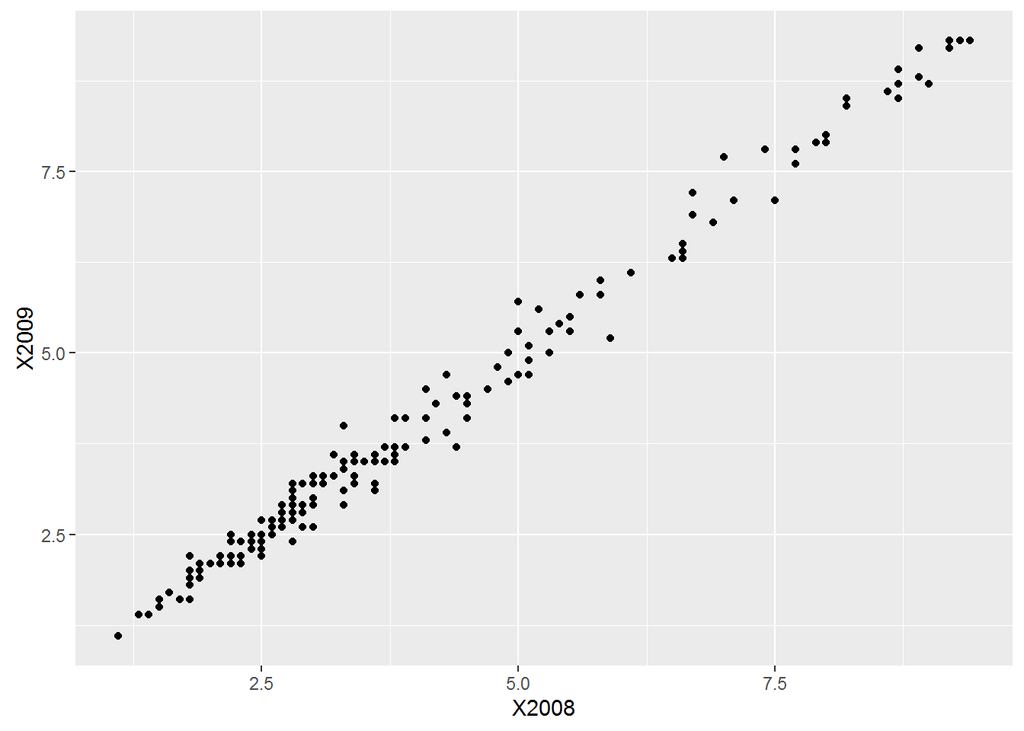

```r
qplot(x = X2008, y = X2009, data = subset(cpi, !is.na(X2009)),
      color = I("black"), fill = I("red"))
```

```r
library(gridExtra)
```

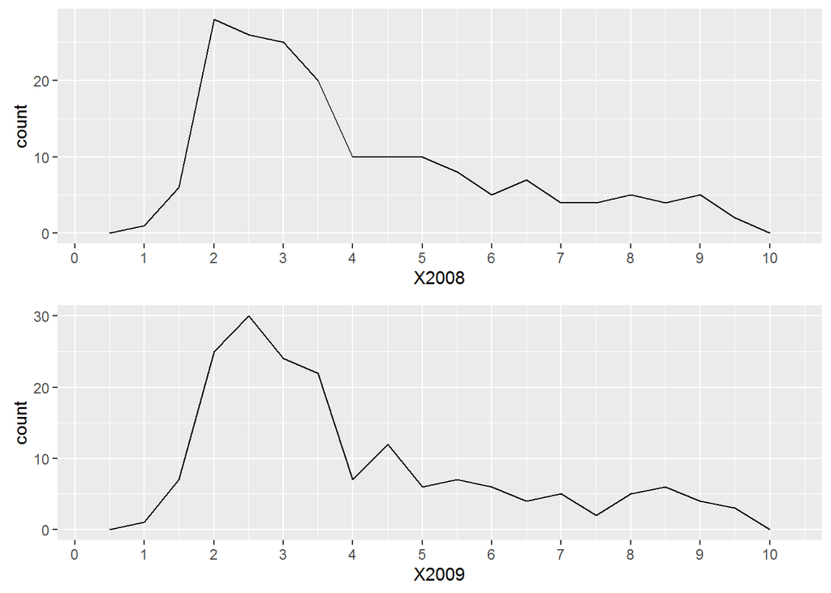

```r
plot1 <- qplot(x = X2008, data = subset(cpi, !is.na(X2008)), geom = "freqpoly", binwidth = .5) +
  scale_x_continuous(breaks = seq(0, 10, 1))
plot2 <- qplot(x = X2009, data = subset(cpi, !is.na(X2009)), geom = "freqpoly", binwidth = .5) +
  scale_x_continuous(breaks = seq(0, 10, 1))
grid.arrange(plot1, plot2, ncol = 1)
```

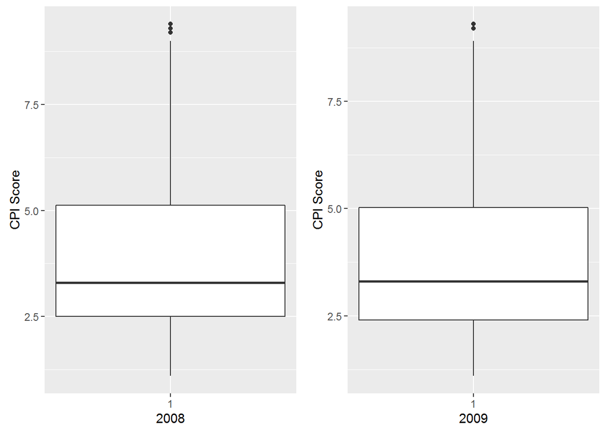

```r
plot3 <- qplot(1, X2008, data = subset(cpi, !is.na(X2008)), geom = "boxplot",
    xlab = "2008", ylab = "CPI Score") +
  scale_x_continuous(breaks = seq(0, 1, 1))
plot4 <- qplot(1, X2009, data = subset(cpi, !is.na(X2009)), geom = "boxplot",
    xlab = "2009", ylab = "CPI Score") +
  scale_x_continuous(breaks = seq(0, 1, 1))
grid.arrange(plot3, plot4, nrow = 1)
```

**When examining a summary of each year and the IQR’s, we see the median value is the same, the mean has decreased by 0.024, the IQR value is the same but has shifted lower, and the maximum score has dropped by 0.1.**

```r
summary(cpi$X2008)
```

```
##    Min. 1st Qu.  Median    Mean 3rd Qu.    Max.
##   1.100   2.500   3.300   4.031   5.125   9.400
```

```r
summary(cpi$X2009)
```

```
##    Min. 1st Qu.  Median    Mean 3rd Qu.    Max.    NA's
##   1.100   2.400   3.300   4.007   5.025   9.300       4
```

```r
IQR(cpi$X2008, na.rm = TRUE)
```

```
## [1] 2.625
```

```r
IQR(cpi$X2009, na.rm = TRUE)
```

```
## [1] 2.625
```

### 16. Exploring Your Friend’s Birthdays

Investigate the distribution of your friends’ birth months and days.

- How many people share your birthday?
- Which month contains the most number of birthdays?
- How many birthdays are in each month?
- Which day of the year has the most number of birthdays?

**Load the facebook friends birthday data into a data frame and examine it’s contents:**

```r
FBfriends <- read.csv("FBfriends.csv" , header = TRUE)
head(FBfriends)
```

```
##                              Title Start.date   End.date Start.time
## 1            Neera Garg's Birthday 04/18/2016 04/19/2016      00:00
## 2     Jane Clarke Ilott's Birthday 04/19/2016 04/20/2016      00:00
## 3           Brian Neale's Birthday 04/22/2016 04/23/2016      00:00
## 4 Angie Cameron Loiseau's Birthday 04/23/2016 04/24/2016      00:00
## 5             Bill Yang's Birthday 04/25/2016 04/26/2016      00:00
## 6           Laura Brown's Birthday 04/30/2016 05/01/2016      00:00
##   End.time Duration                  X Calendar
## 1    00:00    24:00 Friends' Birthdays       NA
## 2    00:00    24:00 Friends' Birthdays       NA
## 3    00:00    24:00 Friends' Birthdays       NA
## 4    00:00    24:00 Friends' Birthdays       NA
## 5    00:00    24:00 Friends' Birthdays       NA
## 6    00:00    24:00 Friends' Birthdays       NA
```

**Separate day and month**

```r
FBfriends$month <- as.numeric(substr(FBfriends$Start.date, 1, 2))
FBfriends$day <- as.numeric(substr(FBfriends$Start.date, 4, 5))
```

How many people share your birthday? **none**

```r
sum(FBfriends$Start.date == 11/13/2016)
```

```
## [1] 0
```

Which month contains the most number of birthdays? **June**

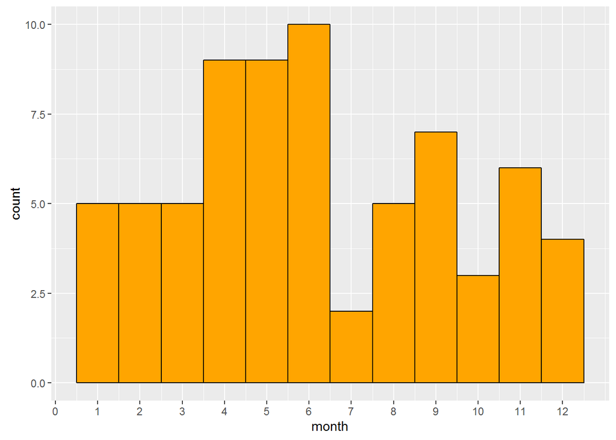

```r
qplot(x = month, data = FBfriends, binwidth = 1, color = I("black"), fill = I("orange")) +
  scale_x_continuous(breaks = seq(0, 12, 1))
```

How many birthdays are in each month?

```r
table(FBfriends$month)
```

```
##
##  1  2  3  4  5  6  7  8  9 10 11 12
##  5  5  5  9  9 10  2  5  7  3  6  4
```

Which day of the year has the most number of birthdays? **18, 27, 30**

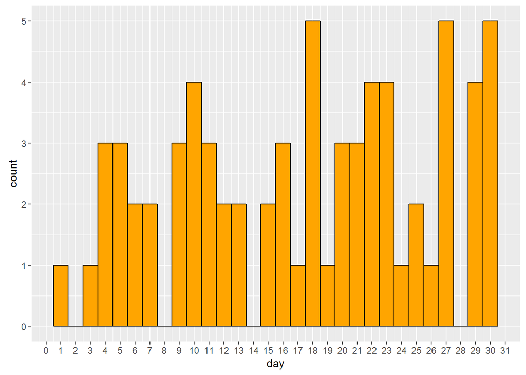

```r
qplot(x = day, data = FBfriends, binwidth = 1, color = I("black"), fill = I("orange")) +
  scale_x_continuous(breaks = seq(0, 31, 1))
```

```r
table(FBfriends$day)
```

```
##
##  1  3  4  5  6  7  9 10 11 12 13 15 16 17 18 19 20 21 22 23 24 25 26 27 29
##  1  1  3  3  2  2  3  4  3  2  2  2  3  1  5  1  3  3  4  4  1  2  1  5  4
## 30
##  5
```